# Sinclair_Chase_HW_6

Chase Sinclair

4/16/2020

### Honor code:

“I have neither given nor received unauthorized assistance on this assignment.” -Chase

# Problem 1

#### (a) Load the USArrests dataset in R, and describe the dataset in your own words, in 2-3 lines.

```r
data("USArrests")
str(USArrests)
```

```
## 'data.frame':    50 obs. of  4 variables:
##  $ Murder  : num  13.2 10 8.1 8.8 9 7.9 3.3 5.9 15.4 17.4 ...
##  $ Assault : int  236 263 294 190 276 204 110 238 335 211 ...
##  $ UrbanPop: int  58 48 80 50 91 78 77 72 80 60 ...
##  $ Rape    : num  21.2 44.5 31 19.5 40.6 38.7 11.1 15.8 31.9 25.8 ...
```

The dataset USArrests contains 50 observations from the 50 different states and 4 variables including: Murder arrests (per 100,000), Assult arrests (per 100,000), Percent of urban population, and Rape arrests (per 100,000). The data comes from the year 1973 and is widely popular in R programming.

#### (b)

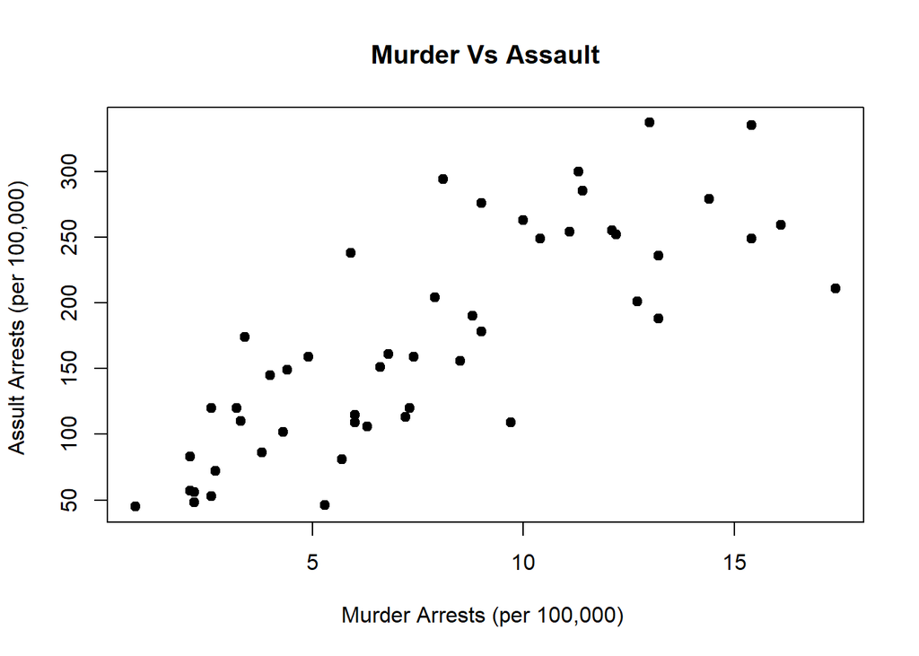

```r
plot(USArrests$Murder,USArrests$Assault, main="Murder Vs Assault",
   xlab="Murder Arrests (per 100,000) ", ylab="Assult Arrests (per 100,000) ", pch=19)
```

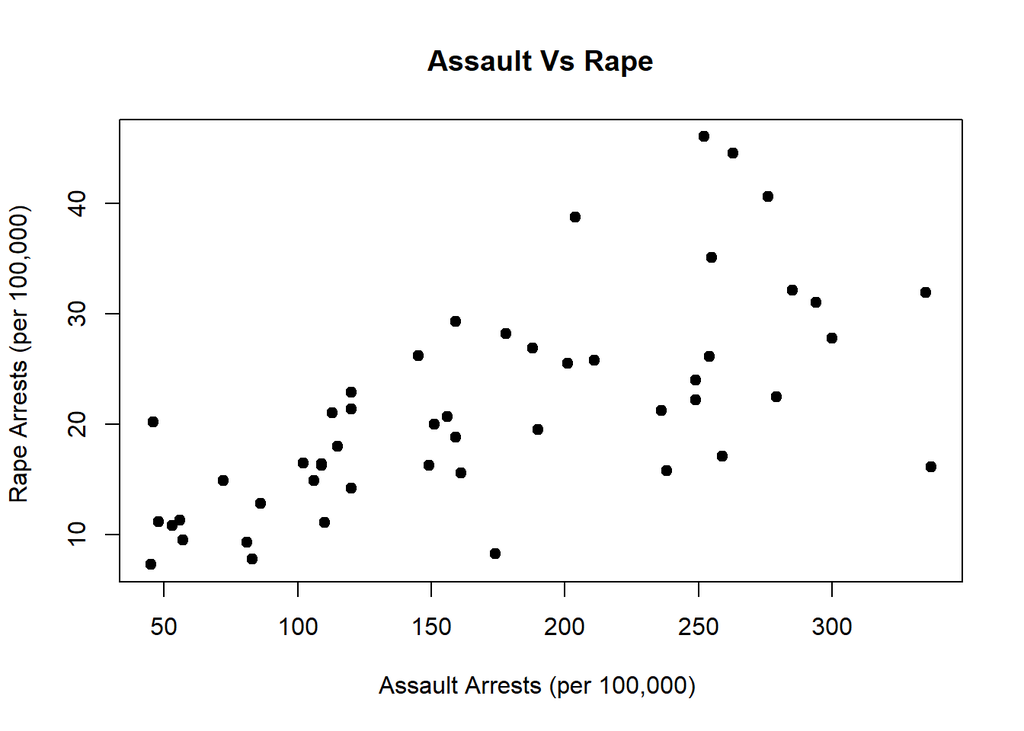

```r
plot(USArrests$Assault, USArrests$Rape, main="Assault Vs Rape",
   xlab="Assault Arrests (per 100,000) ", ylab="Rape Arrests (per 100,000) ", pch=19)
```

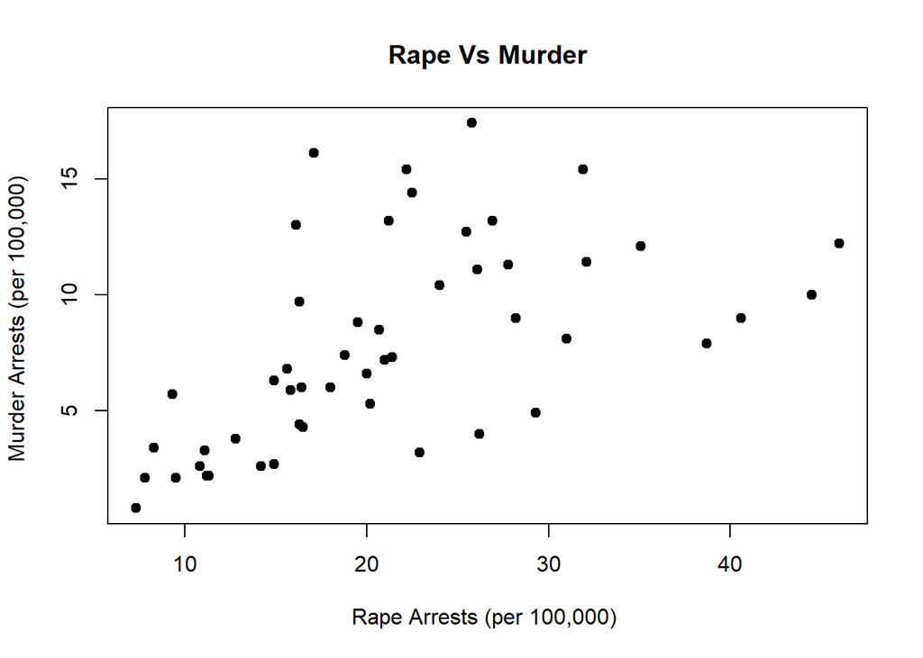

```r
plot(USArrests$Rape,USArrests$Murder, main="Rape Vs Murder",
   xlab="Rape Arrests (per 100,000) ", ylab="Murder Arrests (per 100,000) ", pch=19)
```

From the plots we can see that two of them hold clear positive linear relationships while one could be considered questionably linear positive. Murder Vs Assault and Assault vs Rape are the plots have have clear positive linear relationships while Rape vs Muder has a positive linear relationhip but it is not very strong as a lot of points are randomly scattered.

#### (c) Calculate the mean and standard deviation of the four variables.

```r
apply(USArrests,2,mean)
```

```
##   Murder  Assault UrbanPop     Rape
##    7.788  170.760   65.540   21.232
```

```r
apply(USArrests,2,sd)
```

```
##    Murder   Assault  UrbanPop      Rape
##  4.355510 83.337661 14.474763  9.366385
```

#### (d) Perform principal components analysis of the dataset using R. How many principal components are there? For each principal component, report the standard deviation and the proportion of variance explained.

```r
pr.out=prcomp(USArrests , scale=TRUE)
pr.out$rotation
```

```
##                 PC1        PC2        PC3         PC4
## Murder   -0.5358995  0.4181809 -0.3412327  0.64922780
## Assault  -0.5831836  0.1879856 -0.2681484 -0.74340748
## UrbanPop -0.2781909 -0.8728062 -0.3780158  0.13387773
## Rape     -0.5434321 -0.1673186  0.8177779  0.08902432
```

We have 4 Principle Components.

```r
pr.out$sdev
```

```
## [1] 1.5748783 0.9948694 0.5971291 0.4164494
```

```r
pr.var=pr.out$sdev ^2
pve=pr.var/sum(pr.var)
pve
```

```
## [1] 0.62006039 0.24744129 0.08914080 0.04335752
```

```r
summary(pr.out)
```

```
## Importance of components:
##                           PC1    PC2     PC3     PC4
## Standard deviation     1.5749 0.9949 0.59713 0.41645
## Proportion of Variance 0.6201 0.2474 0.08914 0.04336
## Cumulative Proportion  0.6201 0.8675 0.95664 1.00000
```

PC1 explains 62.0% of the variance in the data PC2 explains 24.7% of the variance in the data PC3 explains 8.9% of the variance in the data PC4 explains 4.3% of the variance in the data

#### (e) How many principal components would you need to explain at least (i) 60% of the total variance? (ii) 75% of the total variance? (iii) 90% of the total variance?

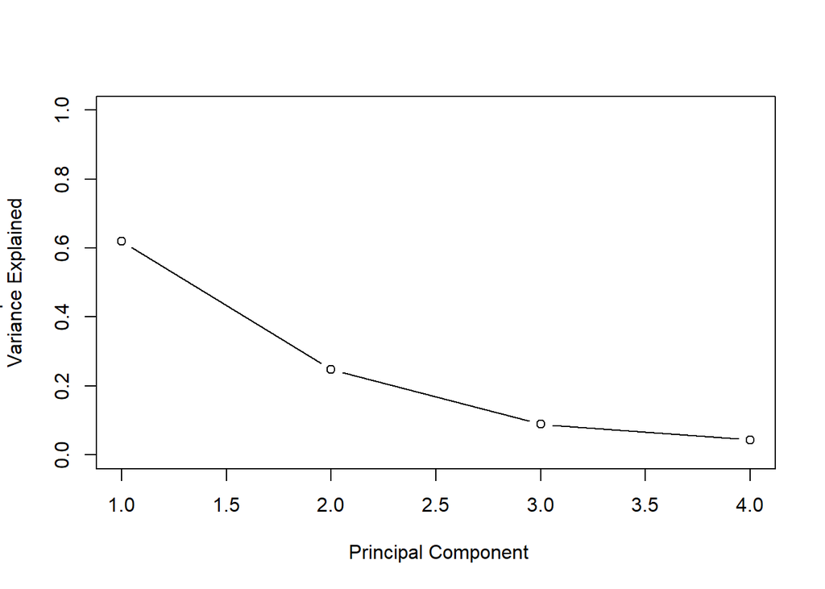

```r
plot(pve,xlab=" Principal Component", ylab="Proportion of
Variance Explained", ylim=c(0,1) ,type="b")
```

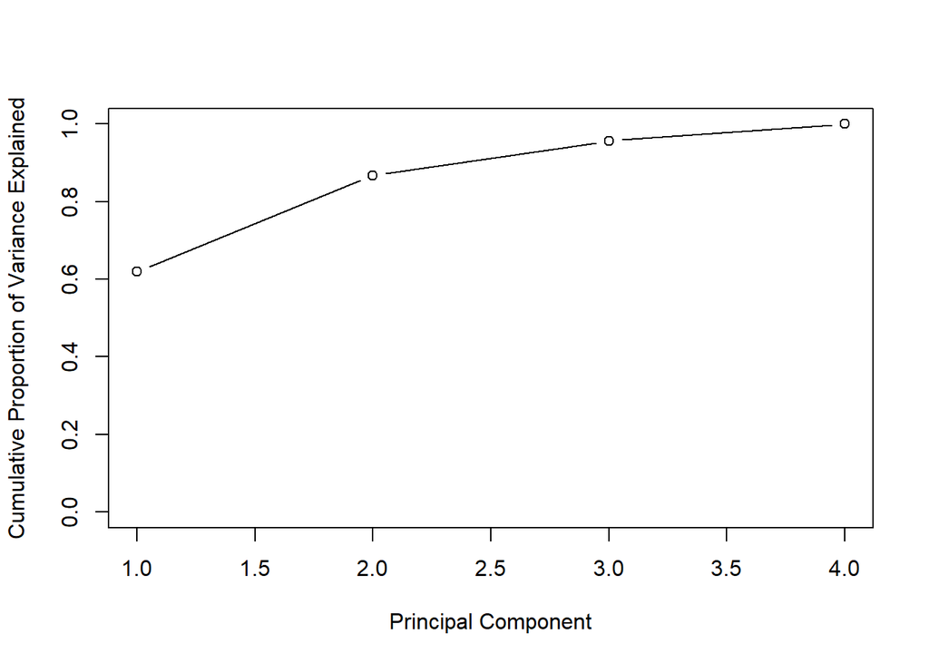

```r
plot(cumsum(pve), xlab="Principal Component", ylab="
Cumulative Proportion of Variance Explained", ylim=c(0,1) ,
type="b")
```

PC1 alone could explain at least 60% of the total variation. PC1 and PC2 coud explain at least 75% of the total variation. PC1, PC2, PC3 could explain at least 90% of the total variation

# Problem 2

#### (a) Recall the NCI60 dataset analyzed in the textbook. Load the NCI60 dataset from the ISLR package in R, and describe the dataset in your own words, in 2-3 lines.

```r
library(ISLR)
nci.labs=NCI60$labs
nci.data=NCI60$data
dim(nci.data)
```

```
## [1]   64 6830
```

```r
table(nci.labs)
```

```
## nci.labs
##      BREAST         CNS       COLON K562A-repro K562B-repro    LEUKEMIA
##           7           5           7           1           1           6
## MCF7A-repro MCF7D-repro    MELANOMA       NSCLC     OVARIAN    PROSTATE
##           1           1           8           9           6           2
##       RENAL     UNKNOWN
##           9           1
```

The NCI60 dataset consists of two elements: “data” and “labs”. The data portion consists of 6830 genes from 64 cancer cell lines formulated in matrix where labs label the different cancer types for the 64 cell lines formulated in vector form.

#### (b) Perform principal components analysis of the dataset using R. How many principal components are there? For the top 10 principal components, report the standard deviation and the proportion of variance explained.

```r
pr.out=prcomp(nci.data, scale=TRUE)
summary(pr.out)                      #Print All
```

```
## Importance of components:
##                            PC1      PC2      PC3      PC4      PC5      PC6
## Standard deviation     27.8535 21.48136 19.82046 17.03256 15.97181 15.72108
## Proportion of Variance  0.1136  0.06756  0.05752  0.04248  0.03735  0.03619
## Cumulative Proportion   0.1136  0.18115  0.23867  0.28115  0.31850  0.35468
##                             PC7      PC8      PC9     PC10     PC11     PC12
## Standard deviation     14.47145 13.54427 13.14400 12.73860 12.68672 12.15769
## Proportion of Variance  0.03066  0.02686  0.02529  0.02376  0.02357  0.02164
## Cumulative Proportion   0.38534  0.41220  0.43750  0.46126  0.48482  0.50646
##                            PC13     PC14     PC15     PC16     PC17     PC18
## Standard deviation     11.83019 11.62554 11.43779 11.00051 10.65666 10.48880
## Proportion of Variance  0.02049  0.01979  0.01915  0.01772  0.01663  0.01611
## Cumulative Proportion   0.52695  0.54674  0.56590  0.58361  0.60024  0.61635
##                            PC19    PC20     PC21    PC22    PC23    PC24
## Standard deviation     10.43518 10.3219 10.14608 10.0544 9.90265 9.64766
## Proportion of Variance  0.01594  0.0156  0.01507  0.0148 0.01436 0.01363
## Cumulative Proportion   0.63229  0.6479  0.66296  0.6778 0.69212 0.70575
##                           PC25    PC26    PC27   PC28    PC29    PC30    PC31
## Standard deviation     9.50764 9.33253 9.27320 9.0900 8.98117 8.75003 8.59962
## Proportion of Variance 0.01324 0.01275 0.01259 0.0121 0.01181 0.01121 0.01083
## Cumulative Proportion  0.71899 0.73174 0.74433 0.7564 0.76824 0.77945 0.79027
##                           PC32    PC33    PC34    PC35    PC36    PC37    PC38
## Standard deviation     8.44738 8.37305 8.21579 8.15731 7.97465 7.90446 7.82127
## Proportion of Variance 0.01045 0.01026 0.00988 0.00974 0.00931 0.00915 0.00896
## Cumulative Proportion  0.80072 0.81099 0.82087 0.83061 0.83992 0.84907 0.85803
##                           PC39    PC40    PC41   PC42    PC43   PC44    PC45
## Standard deviation     7.72156 7.58603 7.45619 7.3444 7.10449 7.0131 6.95839
## Proportion of Variance 0.00873 0.00843 0.00814 0.0079 0.00739 0.0072 0.00709
## Cumulative Proportion  0.86676 0.87518 0.88332 0.8912 0.89861 0.9058 0.91290
##                          PC46    PC47    PC48    PC49    PC50    PC51    PC52
## Standard deviation     6.8663 6.80744 6.64763 6.61607 6.40793 6.21984 6.20326
## Proportion of Variance 0.0069 0.00678 0.00647 0.00641 0.00601 0.00566 0.00563
## Cumulative Proportion  0.9198 0.92659 0.93306 0.93947 0.94548 0.95114 0.95678
##                           PC53    PC54    PC55    PC56    PC57   PC58    PC59
## Standard deviation     6.06706 5.91805 5.91233 5.73539 5.47261 5.2921 5.02117
## Proportion of Variance 0.00539 0.00513 0.00512 0.00482 0.00438 0.0041 0.00369
## Cumulative Proportion  0.96216 0.96729 0.97241 0.97723 0.98161 0.9857 0.98940
##                           PC60    PC61    PC62    PC63      PC64
## Standard deviation     4.68398 4.17567 4.08212 4.04124 2.148e-14
## Proportion of Variance 0.00321 0.00255 0.00244 0.00239 0.000e+00
## Cumulative Proportion  0.99262 0.99517 0.99761 1.00000 1.000e+00
```

```r
pr.out$sdev[1:10]                    # Print top ten PC means
```

```
##  [1] 27.85347 21.48136 19.82046 17.03256 15.97181 15.72108 14.47145 13.54427
##  [9] 13.14400 12.73860
```

```r
pr.var=pr.out$sdev ^2
pve=pr.var/sum(pr.var)
pve[1:10]                            # Print top ten PC proportion of variances
```

```
##  [1] 0.11358942 0.06756203 0.05751842 0.04247554 0.03734972 0.03618630
##  [7] 0.03066222 0.02685903 0.02529498 0.02375869
```

#### (c) How many principal components would you need to explain at least (i) 60% of the total variance? (ii) 75% of the total variance? (iii) 90% of the total variance?

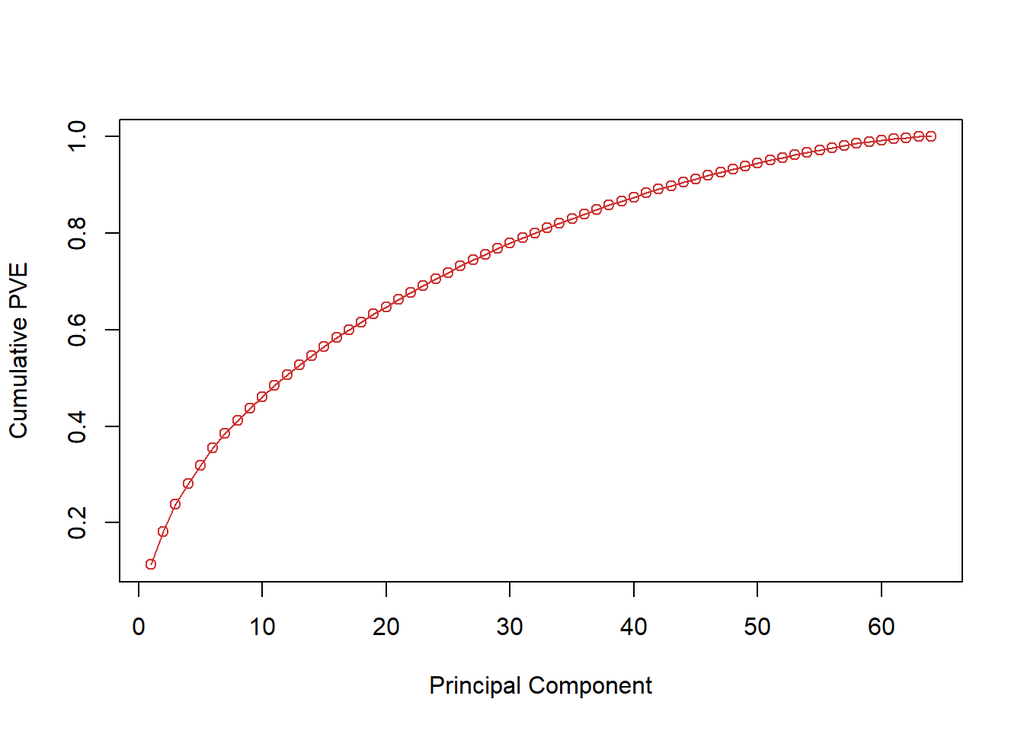

```r
plot(cumsum(pve), type="o", ylab="Cumulative PVE", xlab=" Principal Component ", col="brown3")
```

1. The first 17 PCs explain at least 60% of the total variance
2. The first 28 PCs explain at least 75% of the total variance
3. The first 44 PCs explain at least 90% of the total variance

#### (d) Explain why there is a drastic difference between your answers to 1(e) and 2(c).

The second dataset has manymore PCs then the first dataset. Having more PCs means that the variation will be caused by more variables and spread out between them. In the first dataset, we only had 4 PC’s so the variation can only be between 4 variables.

# Problem 3

#### (a) Load the iris dataset in R. We are going to consider sepal and petal dimensions as features for clustering, and will ignore species.

```r
str(iris)
```

```
## 'data.frame':    150 obs. of  5 variables:
##  $ Sepal.Length: num  5.1 4.9 4.7 4.6 5 5.4 4.6 5 4.4 4.9 ...
##  $ Sepal.Width : num  3.5 3 3.2 3.1 3.6 3.9 3.4 3.4 2.9 3.1 ...
##  $ Petal.Length: num  1.4 1.4 1.3 1.5 1.4 1.7 1.4 1.5 1.4 1.5 ...
##  $ Petal.Width : num  0.2 0.2 0.2 0.2 0.2 0.4 0.3 0.2 0.2 0.1 ...
##  $ Species     : Factor w/ 3 levels "setosa","versicolor",..: 1 1 1 1 1 1 1 1 1 1 ...
```

```r
species <- as.list(iris$Species)
species <- unlist(species)
iris <- iris[1:4]
```

#### (b) Perform hierarchical clustering on the data and cut the hierarchical clustering tree at 3 clusters.

```r
iris_dist <- dist(iris, method = "euclidean")
hier <- hclust(iris_dist, method = "complete")
hierCut <- cutree(hier, 3)
```

#### (c) Perform k-means clustering of the data with k=3 clusters.

```r
model_3 <- kmeans(iris, centers = 3)
```

#### (d) For both clustering methods, report the two-way table with actual species and clusters. What is your interpretation from the two tables?

```r
table(species, hierCut)
```

```
##             hierCut
## species       1  2  3
##   setosa     50  0  0
##   versicolor  0 23 27
##   virginica   0 49  1
```

```r
table(species, model_3$cluster)
```

```
##
## species       1  2  3
##   setosa      0 50  0
##   versicolor 48  0  2
##   virginica  14  0 36
```

The k-means method for clustering is a better method according to the tables as it does a better job at seperating the species when clustering.